# HW1: NYT API

Patty Park

2024-04-09

## Assignment (Due Tuesday 4/9 11:59pm)

Reminder: Please suppress all long and extraneous output from your submissions (ex: lists of tokens).

1. Create a free New York Times account (https://developer.nytimes.com/get-started)

## Create the url with API included to get access to article headlines

```r
#create the query url
url <- paste("http://api.nytimes.com/svc/search/v2/articlesearch.json?q=haaland&api-key=",API_KEY, sep ="")

#send the request, receive the response, and flatten
t <- fromJSON(url, flatten = T)
```

2. Pick an interesting environmental key word(s) and use the {jsonlite} package to query the API. Pick something high profile enough and over a large enough time frame that your query yields enough articles for an interesting examination.

```r
#define a term to scrape the nyt search url
term1 <- "earth"
begin_date <- "20210120" #beginning date
end_date <- "20230401" #end date

#construct the query url using API operators
baseurl <- paste0("http://api.nytimes.com/svc/search/v2/articlesearch.json?q=",
                  term1,
                  "&begin_date=", begin_date,
                  "&end_date=", end_date,
                  "&facet_filter=true&api-key=", API_KEY)

#examine our query url
baseurl
```

```
## [1] "http://api.nytimes.com/svc/search/v2/articlesearch.json?q=earth&begin_date=20210120&end_date=20230401&facet_filter=true&api-key=7aMhkl8aJMmmZTC70FDDG8jCULWJgnLa"
```

```r
#run initial query
initialQuery <- fromJSON(baseurl)

#maxPages <- round((initialQuery$response$meta$hits[1] / 10)-1)
maxPages <- 10

#initiate a list to hold results of our for loop
pages <- list()

#loop
for(i in 1:maxPages){
  nytSearch <- fromJSON(paste0(baseurl, "&page=", i), flatten = TRUE) %>% data.frame()
  message("Retrieving page ", i)
  pages[[i+1]] <- nytSearch #iterate to request all these pages
  Sys.sleep(12) #slow down how often we send request
}

#bind the pages and create a tibble
nyt_df <- bind_rows(pages)
```

3. Recreate the publications per day and word frequency plots using the first paragraph field. This time filter on the response.docs.news_desk variable to winnow out irrelevant results.
- Make some (at least 3) transformations to the corpus including: add context-specific stopword(s), stem a key term and its variants, remove numbers)

## Response.docs.news_desk

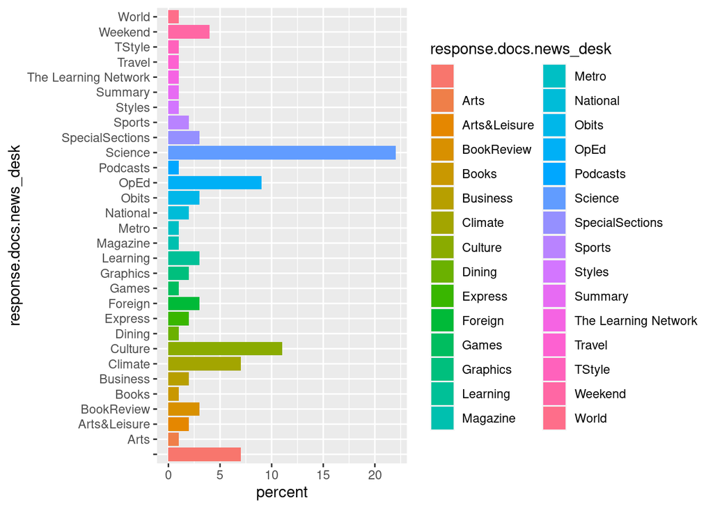

```r
#with response.docs.news_desk

nyt_df %>%
  group_by(response.docs.news_desk) %>%
  summarize(count=n()) %>% #This creates a new data frame with the count of records for each type_of_material.
  mutate(percent = (count / sum(count))*100) %>% #add percent of total column
  ggplot() +
  geom_bar(aes(y=percent, x=response.docs.news_desk, fill=response.docs.news_desk), stat = "identity") + coord_flip()
```

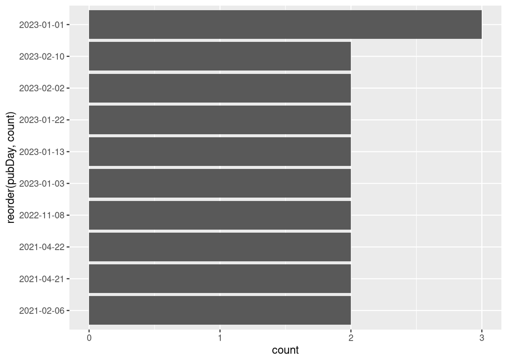

```r
#with response.docs.news_desk, find the publication date

nyt_df %>%
  mutate(pubDay=gsub("T.*","",response.docs.pub_date)) %>% #replace t.* with a comma
  group_by(pubDay) %>%
  summarise(count=n()) %>%
  filter(count >= 2) %>%
  ggplot() +
  geom_bar(aes(x=reorder(pubDay, count), y=count), stat="identity") +
  coord_flip() #put dates on y axis
```

```r
#with response.docs.news_desk

#find first paragraph field
#names(nyt_df)
#head(nyt_df[,1:6])

tokenized <- nyt_df %>%
  filter(response.docs.news_desk != c("culture", "leisure")) %>%
  unnest_tokens(word, response.docs.lead_paragraph)

#use tidytext::unnest_tokens to put in tidy form.
#tokenized[,"word"]
```

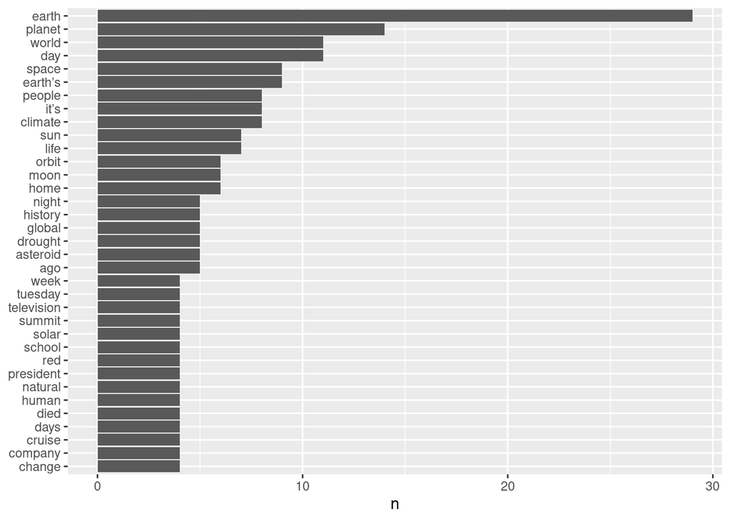

```r
#with response.docs.news_desk

#load stop words
data(stop_words)

#stop word anti_join
tokenized <- tokenized %>%
  anti_join(stop_words)

#plot to see most common words that appear more than 10 times
tokenized %>%
  count(word, sort = TRUE) %>%
  filter(n > 3) %>%
  mutate(word = reorder(word, n)) %>%
  ggplot(aes(n, word)) +
  geom_col() +
  labs(y = NULL)
```

## response.docs.headline.main

4. Recreate the publications per day and word frequency plots using the headlines variable (response.docs.headline.main). Compare the distributions of word frequencies between the first paragraph and headlines. Do you see any difference?

```r
#with response.docs.headline.main

#find first paragraph field
#names(nyt_df)
#head(nyt_df[,1:6])
#The 6th column, "response.doc.lead_paragraph", is the one we want here.
#nyt_df[6]

tokenized <- nyt_df %>%
  filter(response.docs.headline.main != c("culture", "leisure")) %>%
  unnest_tokens(word, response.docs.headline.main)

#use tidytext::unnest_tokens to put in tidy form.
#tokenized[,"word"]
```

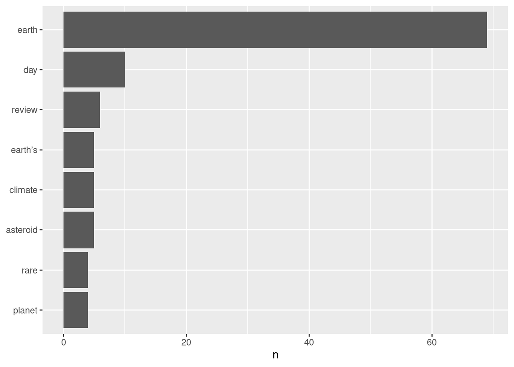

```r
#with response.docs.headline.main

#load stop words
data(stop_words)

#stop word anti_join
tokenized <- tokenized %>%
  anti_join(stop_words)

#plot to see most common words that appear more than 3 times
tokenized %>%
  count(word, sort = TRUE) %>%
  filter(n > 3) %>%
  mutate(word = reorder(word, n)) %>%
  ggplot(aes(n, word)) +
  geom_col() +
  labs(y = NULL)
```